# Network Analysis

Dr. Suat ATAN

07 04 2021

# ABC

KÜÇÜK

BÜYÜK

# Week 6

- Subgroups & Communities
- Cliques
- K-Core
- Modularity
- Community Detection Methods

# Community definition

Wassserman and Faust, Social Network Analysis, Methods and Applications

" A community is subset of actors among whom there are relatively strong, direct, **intense**, frequent of positive ties"

# Key Element: The Social Cohesion

- One way to think about network subgroups is through **social cohesion**.
- This approach is so intuitive that it led to a number of the earliest techniques for identifying network subgroups.
- i.e: Cliques

# What is a community

- Sometimes visually detectable
- Have more connections among each according to other nodes
- It is not “random”

# Where is a community?

The strength of weak ties, Granovetter (1973) suggested that many social networks are made up of relatively densely connected subgroups.

Luke, Douglas A - A User’s Guide to Network Analysis

# Where is a community?

Many disciplines have theories that assume that larger social systems are made up of distinguishable subgroups, for example sociologists consider social classes; psychologists examine small group behavior, and public health examine health disparities between different social groups.

Luke, Douglas A - A User’s Guide to Network Analysis

# A Community Example

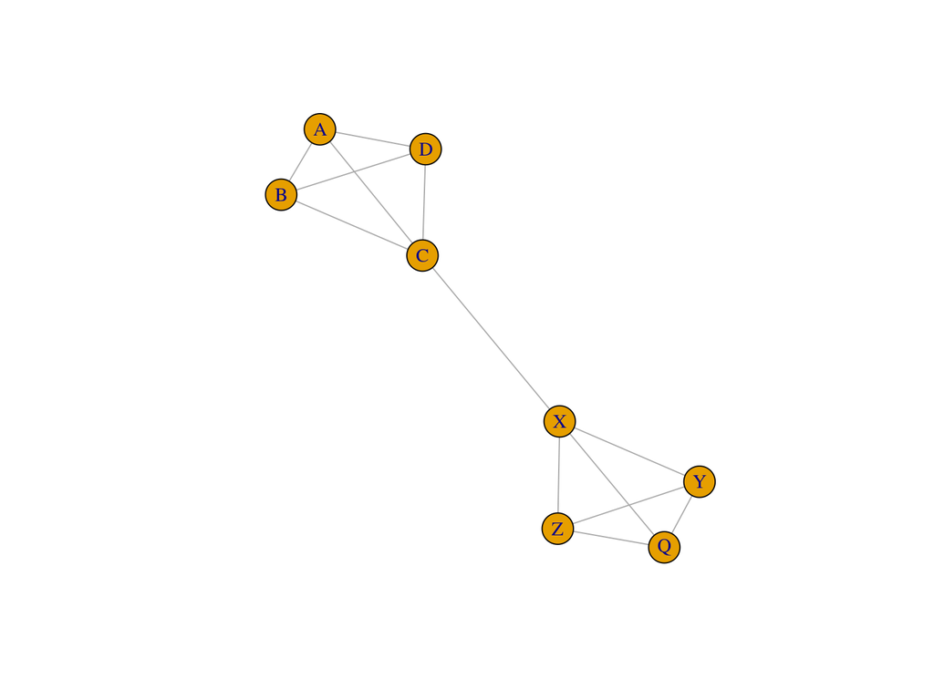

# Hidden Communities

- In most real-world social networks the communities are not as visible
- Systematic analysis or observation will be required to reveal it.
- How ?

# Hidden Communities (Where are the communities?)

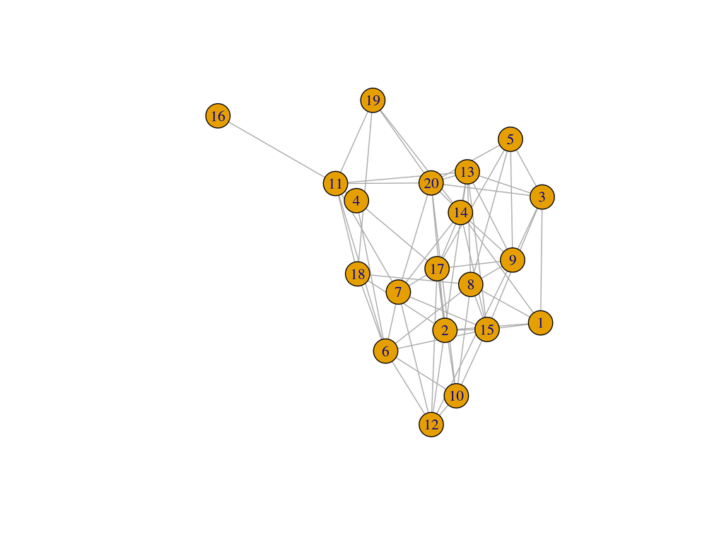

# Clique

- Cliques are one of the simplest types of cohesive subgroups, and because of their straightforward definition are also one of the easiest types to understand.
- A clique is a **maximally complete subgraph**; that is, it is a subset of nodes that have all possible ties among them.

Luke, Douglas A - A User’s Guide to Network Analysis

# Clique Example / Tasks:

- Focus on the next slide and think
- Detect the communities visually
- Why they are community?
- What about X and C ?

# Clique Example

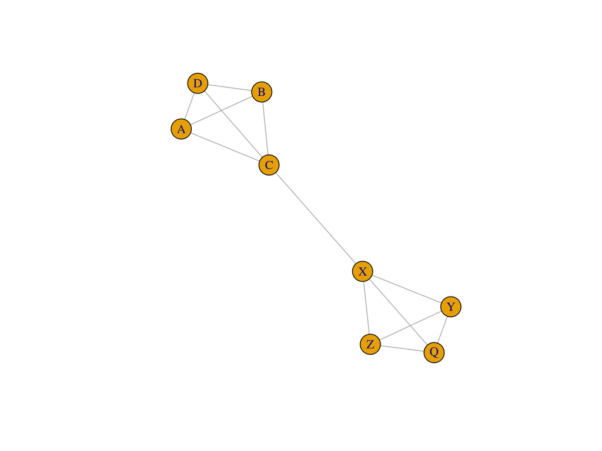

# Cliques

# Clique Definition

- Fully connected subgroups
- Dyads are fully connected but they are not defined as “clique”
- Isn’t very conservative?

# Just one missing connection!

It is no longer a clique:

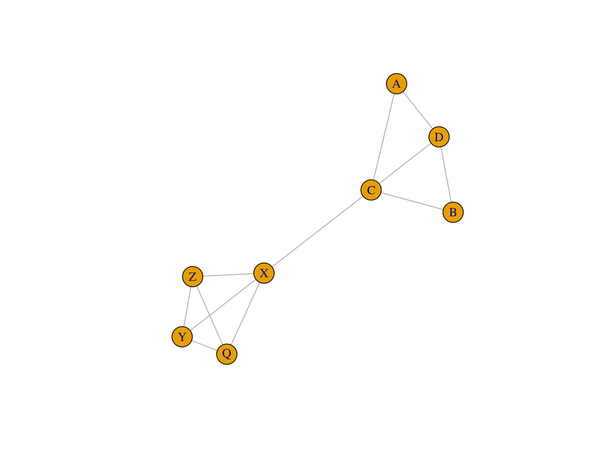

# Cliques 1 (R)

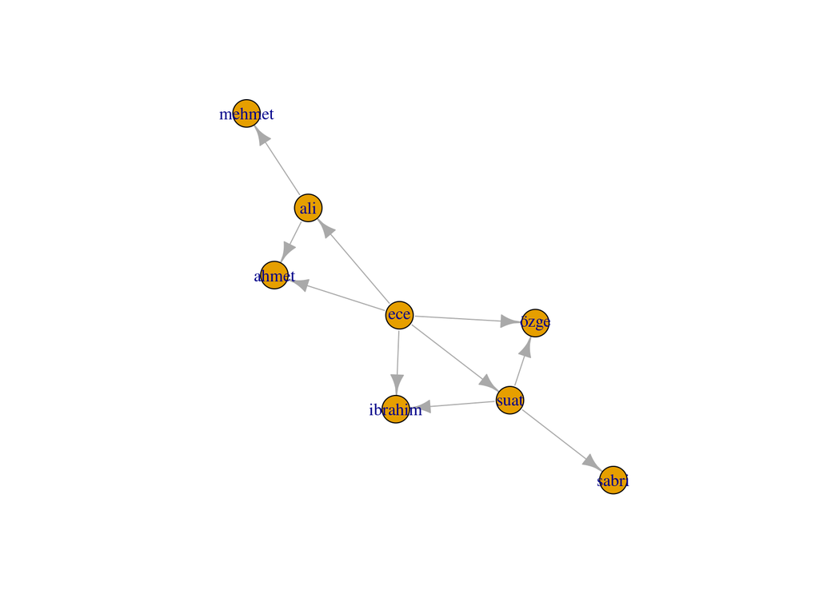

# Cliques 2 (R)

```r
cliques(g2,min = 3)
```

```
## [[1]]
## + 3/8 vertices, named, from 62c72aa:
## [1] ece     suat    ibrahim
##
## [[2]]
## + 3/8 vertices, named, from 62c72aa:
## [1] ece  suat özge
##
## [[3]]
## + 3/8 vertices, named, from 62c72aa:
## [1] ece   ali   ahmet
```

# Clique is not realistic definition

Cliques, have major disadvantage that reduce their utility in real-world social network analysis. A clique is a very conservative definition of a community.

# K-Core

- Variations on the clique concept have been proposed.
- A popular alternative is the k-core.
- **Formal Definition**: A k-core is a **maximal subgraph** where each node is connected to at least k other nodes in the subgraph ?

# K-Core (Step by Step Definition)

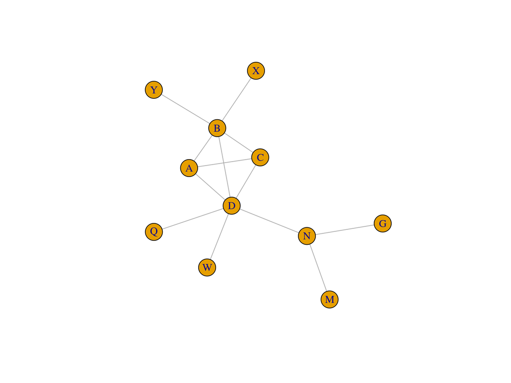

# K-Core 1

- Delete the nodes have only one connection
- What remains?
- K-Core: 2 subgraph

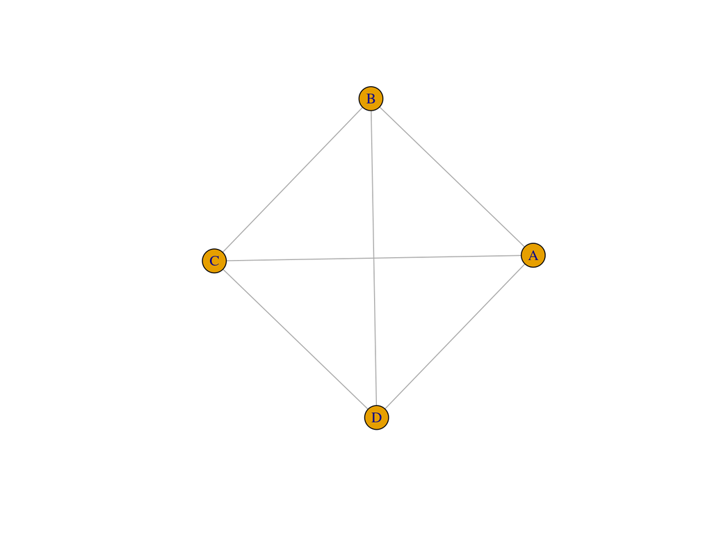

# K-Core 2

Distributed k-Core Decomposition, March 2011,IEEE Transactions on Parallel and Distributed Systems 24(2)

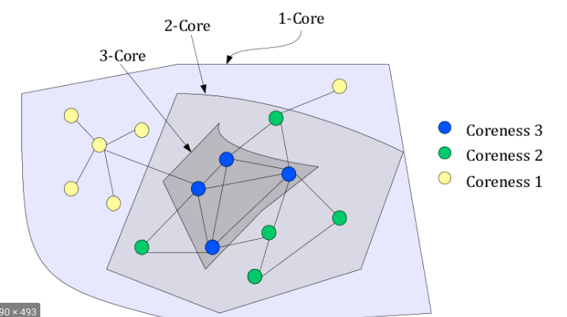

# K-Core (R)

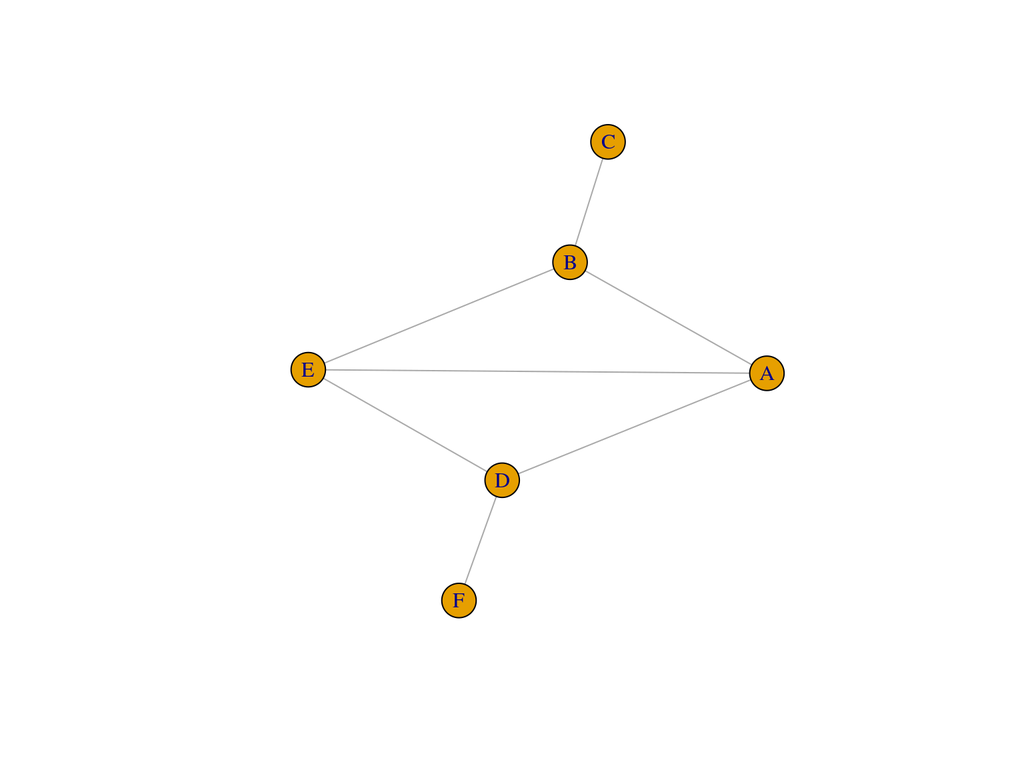

# K-Core (R)

- A,B,E,D are minimum 2 connection. They are members of k-core:2
- C,F is minimum (just) one connection. They are members of k-core:1

```r
coreness(golem)
```

```
## A B C D E F
## 2 2 1 2 2 1
```

# Colorize K-Core 1

```r
golem <- set_vertex_attr(golem,"core",
                         index= V(golem),
                         coreness(golem))
```

# Colorize K-Core 2

```
## [1] 2 2 1 2 2 1
```

# Colorize K-Core 3

```r
V(golem)$color = ifelse(V(golem)$core ==1,
                        "red",
                        "green")
V(golem)$color
```

```
## [1] "green" "green" "red"   "green" "green" "red"
```

# Colorize K-Core 4

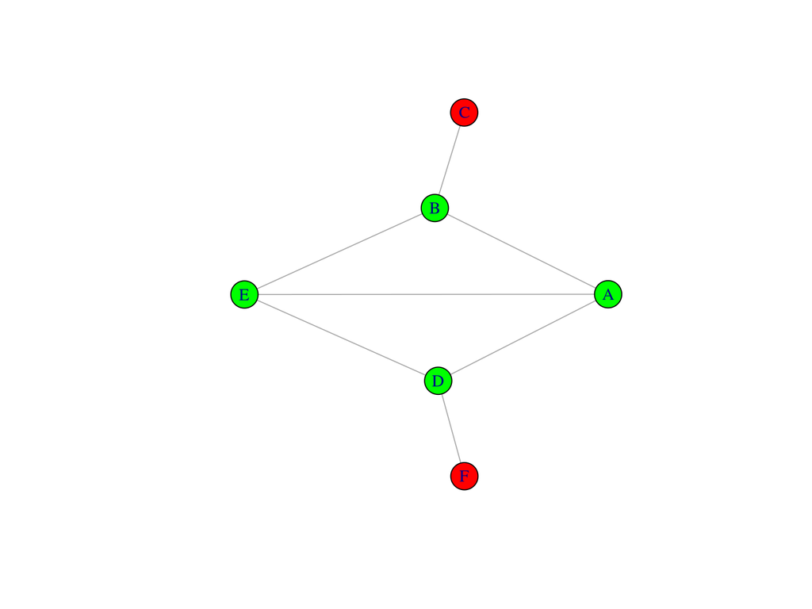

# K-Core For Complex Network (R) 1

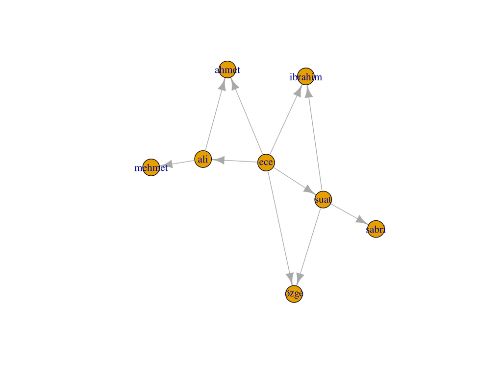

```r
df2 <- read.csv("../data/02.csv")
g2 <- graph_from_data_frame(df2)
plot(g2)
```

# K-Core For Complex Network (R) 2

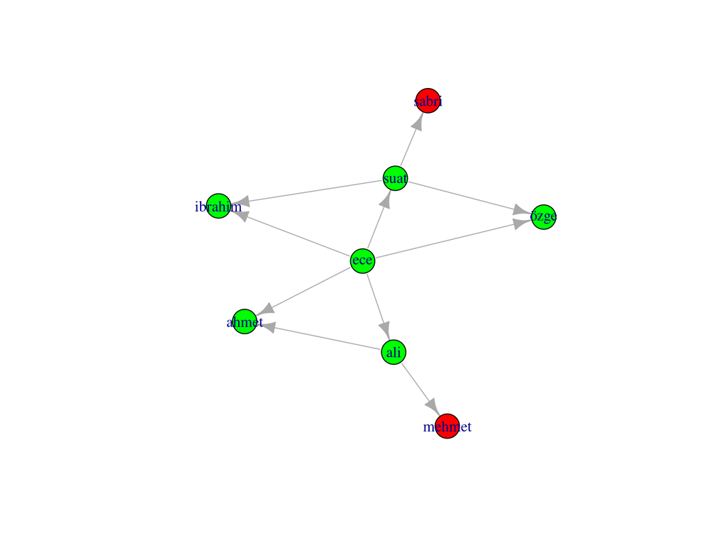

```r
g2 <- set_vertex_attr(g2,"core",
                      index= V(g2),
                      coreness(g2))
V(g2)$color = ifelse(V(g2)$core ==1,"red","green")
plot(g2)
```

# K-Core For Random Game (R) 3

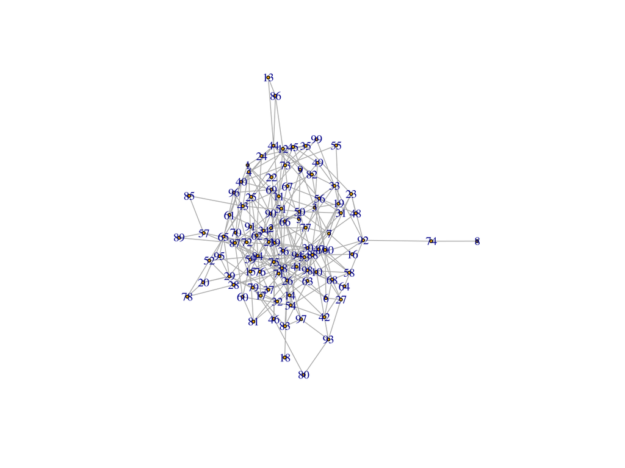

```r
bignet <- random.graph.game(n = 100,
                            p.or.m = 1/20,
                            directed = F)
plot(bignet,vertex.label.cex=0.9,vertex.size=2)
```

# K-Core For Random Game(R) 4

```r
coreness(bignet)
```

```
##   [1] 3 3 3 3 3 3 3 1 3 3 3 3 2 3 3 2 3 1 3 3 3 3 3 3 3 3 3 3 3 3 3 3 3 3 3 3 3
##  [38] 3 3 3 3 3 3 3 3 3 3 3 3 3 3 3 3 3 2 3 2 3 3 3 3 3 3 3 3 3 3 3 3 3 3 3 3 1
##  [75] 3 3 3 3 3 2 3 3 3 3 2 2 3 3 2 3 3 3 3 3 3 3 3 3 2 3
```

# K-Core For Random Game(R) 5

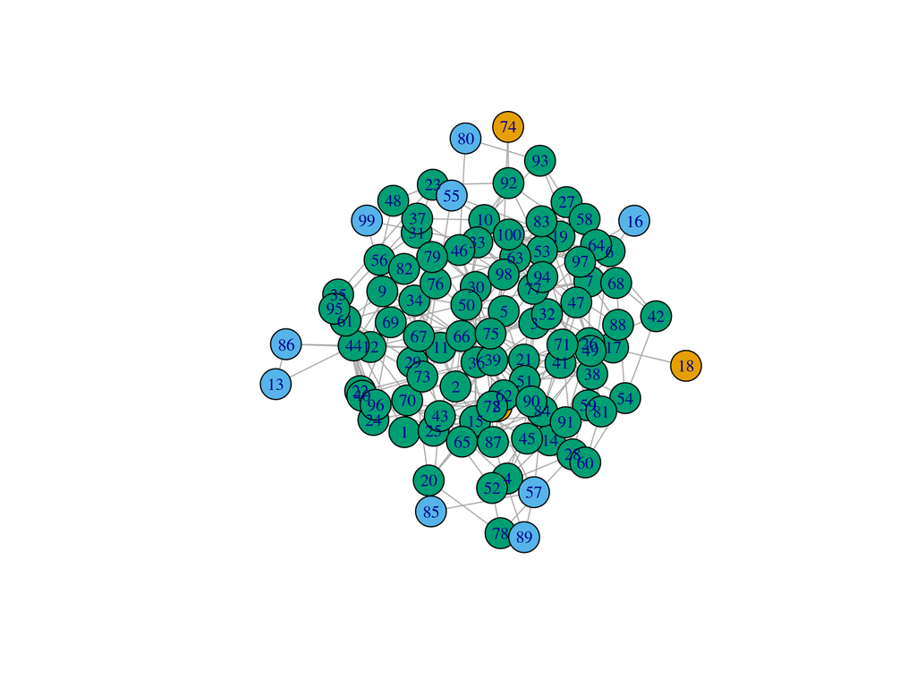

```r
bignet <- set_vertex_attr(bignet,"core",
                          index= V(bignet),
                          coreness(bignet))
V(bignet)$color = V(bignet)$core
plot(bignet,vertex.label.cex=0.9,
     layout=layout.kamada.kawai(bignet))
```

# Modularity Definition

> Modularity is a measure of the structure of the net-work, specifically the extent to which nodes exhibit clustering where there is greater density within the clusters and less density between them (Newman2006)

# Case 1: Xenophobic

```r
moda <- read.csv("../data/modular-a.csv")
moda
```

```
##        person1    person2
## 1  raskolnikov smerdyakov
## 2   smerdyakov     petrov
## 3       petrov   zamyotov
## 4  raskolnikov   zamyotov
## 5  raskolnikov     petrov
## 6       nilgun       ayse
## 7       nilgun        can
## 8          can       ayse
## 9          can       arzu
## 10        arzu     nilgun
## 11         can   zamyotov
```

# Case 1: Set origins: Russian or Turkish

```r
gmoda <- graph_from_data_frame(moda,directed = FALSE)
grepl("ov","raskov")
```

```
## [1] TRUE
```

```r
V(gmoda)$origin = ifelse(grepl("ov",
                               V(gmoda)$name),"russian","turkish")
V(gmoda)$color = ifelse(grepl("ov",
                              V(gmoda)$name),"blue","red")
V(gmoda)$origin_id = ifelse(grepl("ov",
                                  V(gmoda)$name),1,2)
V(gmoda)$origin
```

```
## [1] "russian" "russian" "russian" "turkish" "turkish" "turkish" "russian"
## [8] "turkish"
```

# Case 1

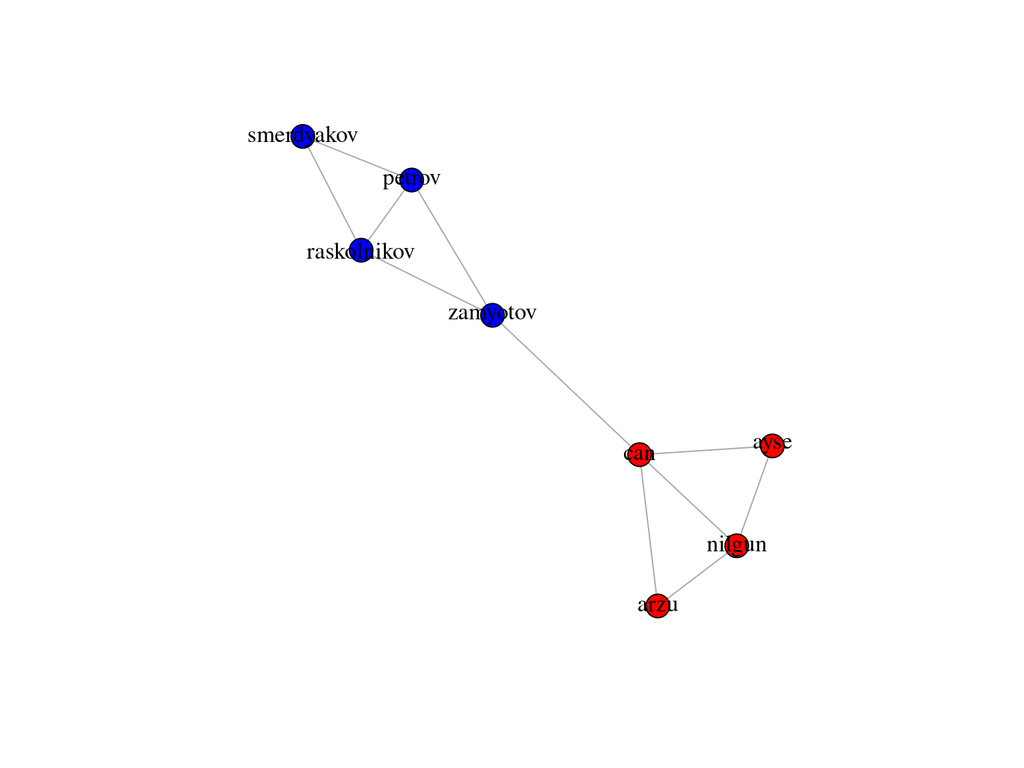

# Modularity of Case 1

Calculation with R:

```r
modularity(gmoda,V(gmoda)$origin_id,)
```

```
## [1] 0.4090909
```

Parameter 1: Graph object, Parameter 2: Vertices

# Case 2: Multicultural

```r
modb <- read.csv("../data/modular-b.csv")
modb
```

```
##        person1    person2
## 1  raskolnikov       ayse
## 2         ayse     petrov
## 3       petrov       arzu
## 4  raskolnikov       arzu
## 5  raskolnikov     petrov
## 6       nilgun smerdyakov
## 7       nilgun        can
## 8          can smerdyakov
## 9          can   zamyotov
## 10    zamyotov     nilgun
## 11         can   zamyotov
```

# Case 2: Set origins

```r
gmodb <- graph_from_data_frame(modb,directed = FALSE)
V(gmodb)$origin = ifelse(grepl("ov",
                               V(gmodb)$name),
                         "russian","turkish")
V(gmodb)$color = ifelse(grepl("ov",
                              V(gmodb)$name),
                        "blue","red")
V(gmodb)$origin_id = ifelse(grepl("ov",
                                  V(gmodb)$name),
                            1,2)
V(gmodb)$origin
```

```
## [1] "russian" "turkish" "russian" "turkish" "turkish" "russian" "turkish"
## [8] "russian"
```

# Case 2: Multicultural

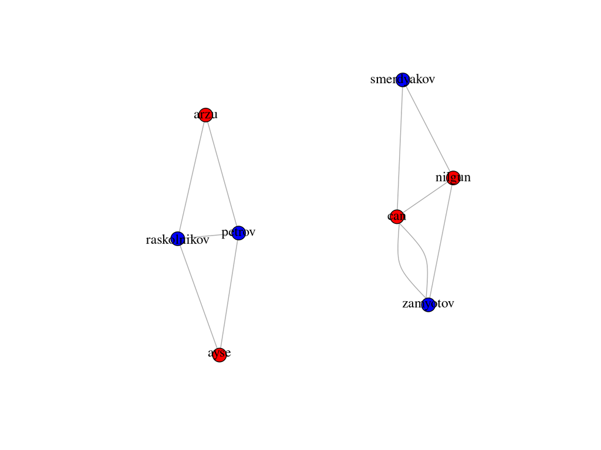

# Modularity of Case 2

Calculation with R

```r
modularity(gmodb,V(gmodb)$origin_id)
```

```
## [1] -0.3181818
```

Parameter 1: Graph object, Parameter 2: Vertices

# The End

Thanks

Dr. Suat ATAN